# Report Exercise Chapter 10

Samuel Bichsel

## About this file

This Markdown file is for the report exercise of Chapter 10 (Supervised Machine learning II) of the AGDS Course. This final exercise is about spatial upscaling of a prediction model (using training data from one site to predict test data from a different site) and checking how generalisable that model is. Just like the previous chapter, this is done with knn and FLUXNET data.

## Setup

Setup like said in the book, except use prop = 0.8 to keep 20% of the data for testing purposes.

```r
#make the data wrangling part be a function so I can apply it to both datasets without using way too much code. Yes I am aware this is not very nice looking code and could have been done more optimally but if I can be honest pipe operators confuse me for some reason so I just did it the fastest way I could come up with

wrangle <- function(data){
data |>
   # select only the variables we are interested in
  dplyr::select(TIMESTAMP,
                GPP_NT_VUT_REF,    # the target
                ends_with("_QC"),  # quality control info
                ends_with("_F"),   # includes all all meteorological covariates
                -contains("JSB")   # weird useless variable
                ) |>

  # convert to a nice date object
  dplyr::mutate(TIMESTAMP = ymd(TIMESTAMP)) |>

  # set all -9999 to NA
  dplyr::mutate(across(where(is.numeric), ~na_if(., -9999))) |>

  # retain only data based on >=80% good-quality measurements
  # overwrite bad data with NA (not dropping rows)
  dplyr::mutate(GPP_NT_VUT_REF = ifelse(NEE_VUT_REF_QC < 0.8, NA, GPP_NT_VUT_REF),
                TA_F           = ifelse(TA_F_QC        < 0.8, NA, TA_F),
                SW_IN_F        = ifelse(SW_IN_F_QC     < 0.8, NA, SW_IN_F),
                LW_IN_F        = ifelse(LW_IN_F_QC     < 0.8, NA, LW_IN_F),
                VPD_F          = ifelse(VPD_F_QC       < 0.8, NA, VPD_F),
                PA_F           = ifelse(PA_F_QC        < 0.8, NA, PA_F),
                P_F            = ifelse(P_F_QC         < 0.8, NA, P_F),
                WS_F           = ifelse(WS_F_QC        < 0.8, NA, WS_F)) |>

  # drop QC variables (no longer needed)
  dplyr::select(-ends_with("_QC"))
}



daily_fluxes_Dav <- wrangle(daily_fluxes_Dav <- readr::read_csv("./data/FLX_CH-Dav_FLUXNET2015_FULLSET_DD_1997-2014_1-3.csv"))
daily_fluxes_Lae <- wrangle(daily_fluxes_Lae <- readr::read_csv("./data/FLX_CH-Lae_FLUXNET2015_FULLSET_DD_2004-2014_1-4.csv"))
#so apparently the entire column P_F of daily_fluxes_Lae is of poor quality according to its _QC in the csv document, meaning every value is now NA. This means I have no choice but to drop the entire column :/
daily_fluxes_Lae <- daily_fluxes_Lae[!(colnames(daily_fluxes_Lae)) == "P_F"]

#like previously, I drop the LW_IN_F column as well from the Davos dataset because of the quantity of missing data an a priori not too important nature of the variable
daily_fluxes_Dav <- daily_fluxes_Dav[!(colnames(daily_fluxes_Dav)) == "LW_IN_F"]



# Data splitting
set.seed(123)  # for reproducibility
#



Dav_split <- rsample::initial_split(daily_fluxes_Dav, prop = 0.8, strata = "VPD_F")
Lae_split <- rsample::initial_split(daily_fluxes_Lae, prop = 0.8, strata = "VPD_F")

daily_fluxes_Dav_train <- rsample::training(Dav_split)
daily_fluxes_Dav_test <- rsample::testing(Dav_split)

daily_fluxes_Lae_train <- rsample::training(Lae_split)
daily_fluxes_Lae_test <- rsample::testing(Lae_split)

# The same model formulation is in the previous chapter
pp_Dav <- recipes::recipe(GPP_NT_VUT_REF ~ SW_IN_F + VPD_F + TA_F,
                      data = daily_fluxes_Dav_train) |>
  recipes::step_center(all_numeric(), -all_outcomes()) |>
  recipes::step_scale(all_numeric(), -all_outcomes())

pp_Lae <- recipes::recipe(GPP_NT_VUT_REF ~ SW_IN_F + VPD_F + TA_F,
                      data = daily_fluxes_Lae_train) |>
  recipes::step_center(all_numeric(), -all_outcomes()) |>
  recipes::step_scale(all_numeric(), -all_outcomes())
```

For tuning and selecting k, we use trainControl(method = “cv”) to enable resampling and going through different values of k in order to find the best possible model.

```r
mod_Dav <- caret::train(pp_Dav,
                    data = daily_fluxes_Dav_train |> drop_na(),
                    method = "knn",
                    trControl = caret::trainControl(method = "cv",
                                                    number = 60
                                                    ),
                    tuneGrid = data.frame(k = c(2, 5, 10, 15, 20, 25, 30, 35, 40, 60, 100)),
                    metric = "MAE"
                    )

mod_Lae <- caret::train(pp_Lae,
                    data = daily_fluxes_Lae_train |> drop_na(),
                    method = "knn",
                    trControl = caret::trainControl(method = "cv",
                                                    number = 60
                                                    ),
                    tuneGrid = data.frame(k = c(2, 5, 10, 15, 20, 25, 30, 35, 40, 60, 100)),
                    metric = "MAE"
                    )


mod_Dav
```

```
## k-Nearest Neighbors
##
## 4835 samples
##    7 predictor
##
## Recipe steps: center, scale
## Resampling: Cross-Validated (60 fold)
## Summary of sample sizes: 4755, 4755, 4754, 4754, 4755, 4754, ...
## Resampling results across tuning parameters:
##
##   k    RMSE      Rsquared   MAE
##     2  1.729793  0.6272148  1.305231
##     5  1.537468  0.6922668  1.164880
##    10  1.479620  0.7129451  1.119969
##    15  1.460741  0.7198771  1.106834
##    20  1.452348  0.7230282  1.099995
##    25  1.446174  0.7253641  1.095211
##    30  1.446038  0.7255099  1.097166
##    35  1.444550  0.7260762  1.096475
##    40  1.447452  0.7249409  1.099092
##    60  1.448974  0.7243423  1.102753
##   100  1.454957  0.7225323  1.109882
##
## MAE was used to select the optimal model using the smallest value.
## The final value used for the model was k = 25.
```

```r
mod_Lae
```

```
## k-Nearest Neighbors
##
## 2423 samples
##    7 predictor
##
## Recipe steps: center, scale
## Resampling: Cross-Validated (60 fold)
## Summary of sample sizes: 2383, 2383, 2382, 2383, 2383, 2383, ...
## Resampling results across tuning parameters:
##
##   k    RMSE      Rsquared   MAE
##     2  2.952516  0.5637990  2.273328
##     5  2.662998  0.6270430  2.045540
##    10  2.527679  0.6599496  1.934208
##    15  2.491517  0.6687689  1.896447
##    20  2.472305  0.6737686  1.881410
##    25  2.468720  0.6746537  1.875507
##    30  2.470621  0.6743384  1.877669
##    35  2.473512  0.6737509  1.877284
##    40  2.475576  0.6734364  1.878718
##    60  2.505433  0.6655266  1.899749
##   100  2.550955  0.6531445  1.938677
##
## MAE was used to select the optimal model using the smallest value.
## The final value used for the model was k = 25.
```

Using MAE as a metric to tune the k, the best values are k = 25 for the Models of Davos and Laegern respectively.

## Evaluate models

#### Compare within-site predictions and across-site predictions on the test set for both sites, considering different metrics.

Just like for the exercises of the previous chapter, we use the function eval_model to compare the models. Since there are 2 locations with training and testing data for each, this gives 4 different combinations of training and testing (two within-site, and two across-site predictions).

```r
source("./eval_model.R")

#adding the fitted values by hand since eval_model doesn't do that for me

daily_fluxes_Dav_test <- daily_fluxes_Dav_test |>
    drop_na()

daily_fluxes_Dav_test$Dav_fitted <- predict(mod_Dav, newdata = daily_fluxes_Dav_test)

daily_fluxes_Dav_test$Lae_fitted <- predict(mod_Lae, newdata = daily_fluxes_Dav_test)



daily_fluxes_Lae_test <- daily_fluxes_Lae_test |>
    drop_na()

daily_fluxes_Lae_test$Lae_fitted <- predict(mod_Lae, newdata = daily_fluxes_Lae_test)

daily_fluxes_Lae_test$Dav_fitted <- predict(mod_Dav, newdata = daily_fluxes_Lae_test)
```

#### Davos training, Davos testing set

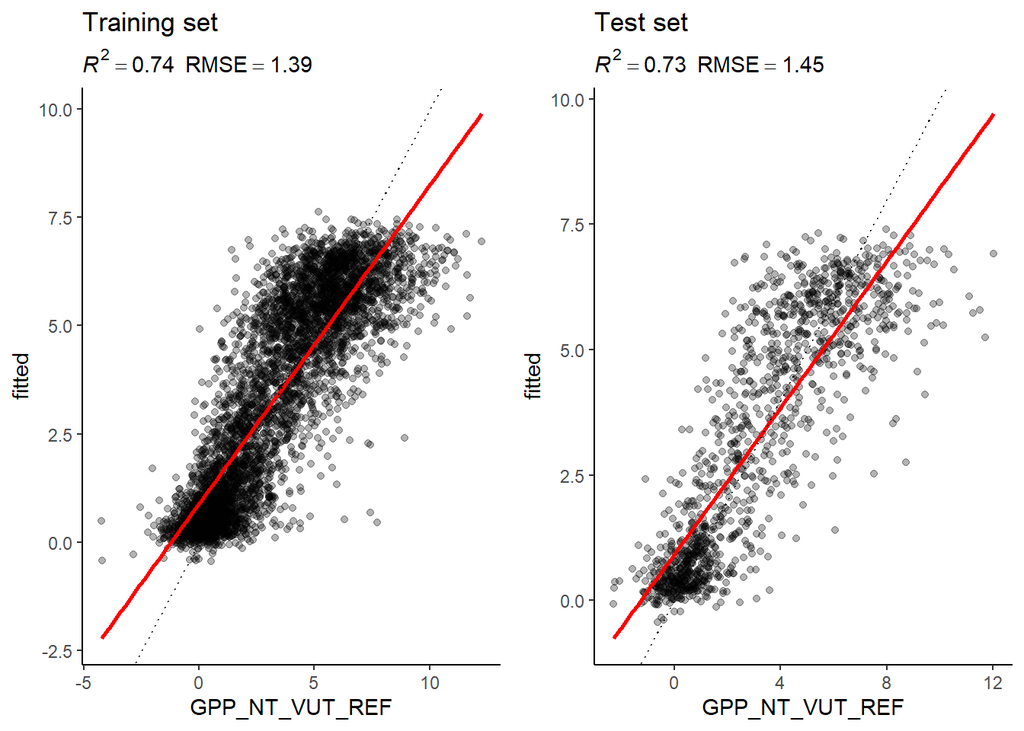

*Figure 1: Evaluation of knn model fit vs. GPP measurements using the Davos training set to predict the Davos test set*

```r
eval_model(mod = mod_Dav, df_train = daily_fluxes_Dav_train, df_test = daily_fluxes_Dav_test)
```

```r
knitr::kable(daily_fluxes_Dav_test |>
    yardstick::metrics(GPP_NT_VUT_REF, Dav_fitted), caption = "*Table 1: Metrics of knn model fit vs. GPP measurements using the Davos training set to predict the Davos test set*")
```

*Table 1: Metrics of knn model fit vs. GPP measurements using the Davos training set to predict the Davos test set*

| .metric | .estimator | .estimate |
| --- | --- | --- |
| rmse | standard | 1.4540969 |
| rsq | standard | 0.7256779 |
| mae | standard | 1.0857985 |

#### Davos training, Laegern testing set

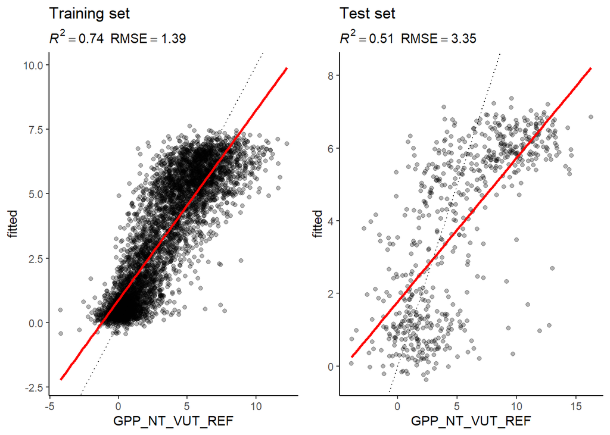

*Figure 2: Evaluation of knn model fit vs. GPP measurements using the Davos training set to predict the Laegern test set*

```r
eval_model(mod = mod_Dav, df_train = daily_fluxes_Dav_train, df_test = daily_fluxes_Lae_test)
```

```r
knitr::kable(daily_fluxes_Lae_test |>
    yardstick::metrics(GPP_NT_VUT_REF, Dav_fitted), caption = "*Table 2: Metrics of knn model fit vs. GPP measurements using the Davos training set to predict the Laegern test set*")
```

*Table 2: Metrics of knn model fit vs. GPP measurements using the Davos training set to predict the Laegern test set*

| .metric | .estimator | .estimate |
| --- | --- | --- |
| rmse | standard | 3.3459669 |
| rsq | standard | 0.5119193 |
| mae | standard | 2.6529500 |